# Presentación 4: Estudio sobre los cursos reprobados de alumnos de UTEC

03 Mayo, 2023

# 1 **Introducción**

Con el objetivo de llegar a ser profesional y dedicarse a lo que les apasiona, muchas personas deciden iniciar su vida universitaria sin saber realmente lo que les espera. Gente de diferentes lugares con distintas costumbres, distinto estilo de vida y distinta educación es reunida en un mismo campus para ser sometidos a las mismas exigencias. Teniendo en cuenta que todos aspiran a la misma meta (ser exitosos en sus estudios universitarios), nos hemos propuesto averiguar cómo es que el estilo de vida de los estudiantes se relaciona con su desempeño académico.

## 1.1 Importancia y justificación

La importancia del tema de estudio radica en **el impacto que tienen las actividades diarias en la salud física y mental de los estudiantes y cómo esta es reflejada en su rendimiento académico.** Sin duda alguna, cualquier factor con margen de mejora debe ser tenido en cuenta para alcanzar el máximo desempeño. Por esto, analizar y comprender cómo es que la cantidad de horas de sueño, la situación económica de una familia u otros factores afectan positiva o negativamente en el estudiante es resulta siendo algo crucial.

## 1.2 Objetivos

El objetivo principal de nuestra investigación es **recopilar información relacionada al modo de vida de los estudiantes de UTEC e información relacionada a sus estudios académicos**, y el posterior riguroso análisis de la misma para determinar las relaciones que existen entre los mismos.

- Determinar relaciones entre el estilo de vida de los estudiantes y su desempeño académico.
- Proponer la adopción de costumbres y métodos de estudio a partir de las relaciones encontradas con el fin de apoyar a los estudiantes en su vida universitaria.

## 1.3 Planificación

La siguiente tabla muestra las características y objetivos que debemos cumplir para cada entrega. Así tendremos cada detalle de nuestro proyecto al día y poder lograr los objetivos propuestos según la rúbrica.

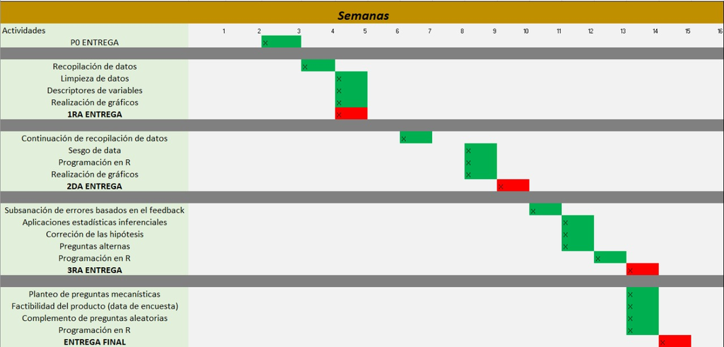

# 2 **Marco Teórico**

## 2.1 **Tipo de muestreo**

En la universidad UTEC, existe una gran cantidad de estudiantes (se aproxima unos ocho mil alumnos) y no siempre se puede acceder a comunicarse con todos ellos. Al inicio se consideró nuestro tipo de muestreo como **aleatorio simple** debido a la gran cantidad de correos masivos que se enviaron por Gmail (aproximadamente seis mil correos) en la que se incluía nuestra encuesta, pero aún así no era seguro que todos hayan recibido el correo o que al menos lo hayan leído. El hecho que una sola persona no leyera el mensaje, hace que no todos tengan la misma probabilidad de participar. Además, el **muestreo aleatorio simple** no siempre es eficaz en muestras muy grandes, así que no sería del todo correcto decir que se usó ese tipo de muestreo. Por otro lado, tenemos el tipo de muestreo **no aleatorio por conveniencia**, en la que se elige a los miembros de nuestra muestra por proximidad y es usada cuando es casi imposible realizar pruebas a toda nuestra población (estudiantes de UTEC). Así que es mucho más seguro decir que se uso este tipo de muestreo.

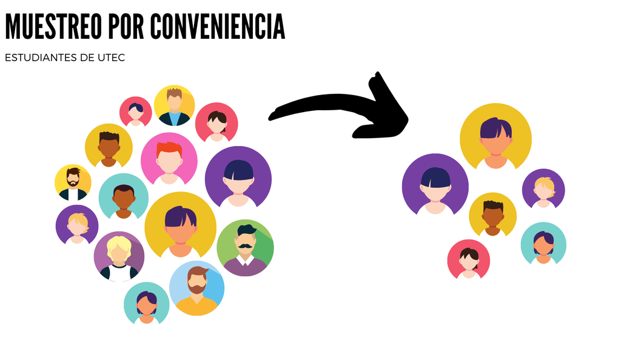

## 2.2 **Obtención de datos**

Para la obtención de datos, se realizará una encuesta a través de Google Forms y, mediante la descarga de información por las hojas de cálculo vinculadas de Google, se procederá a manejar y limpiar la base de datos formada. La encuesta será difundida por medio de las redes sociales más utilizadas por los estudiantes con el fin de tener un mayor alcance.

1. **Población objetivo:** Estudiantes universitarios (no cachimbos) de la universidad UTEC.
2. **Muestra:** 206 estudiantes (no cachimbos) de la universidad UTEC.
3. **Unidad muestral:** Un estudiante (no cachimbo) de la universidad UTEC.
4. **Variables de estudio:** Edad, periodo, carrera, escala, J_curso, N_reprobado, CIENCIA_reprobado, HACS_reprobado, PIER_reprobado, GESTION_reprobado, CARRERA_reprobado, motivo, riesgo, retirado, Motivo_retiro, Horas_estudio, Horas_sueño, Horas_deporte, Prom_ponderado, Prom_primerciclo, Prom_ultimociclo.

## 2.3 **Variables**

| Pregunta | Variable | Tipo | Restricciones |
| --- | --- | --- | --- |
| ¿Cuál es su edad? | Edad | Discreta | Número entero no negativo. |
| ¿En qué periodo ingresó a UTEC? | Periodo | Ordinal | Año de ingreso y periodo separado con guión (2020-1). |
| ¿A qué carrera perteneces? | Carrera | Nominal | Carreras de UTEC. |
| ¿A qué escala del sistema de pensiones de UTEC perteneces? | Escala | Nominal | A - E, Becado por UTEC, Becado por terceros. |
| ¿Has reprobado algún curso? | J_curso | Nominal | Sí / No |
| ¿ Cuántas veces has reprobado? | N_reprobado | Discreta | Número entero no negativo. |
| ¿Qué curso(s) de CIENCIAS GENERALES has reprobado? | Ciencia_reprobado | Nominal | Carreras de CIENCIAS GENERALES |
| ¿Qué curso(s) de HUMANIDADES, ARTE Y CIENCIAS SOCIALES (HACS) has reprobado? | HACS_reprobado | Nominal | Carreras de HACS |
| ¿Qué curso(s) de PROYECTOS INTERDISCIPLINARIOS, TESIS Y REAL LIFE EXPERIENCE has desaprobado? | PIER_reprobado | Nominal | Carreras de PIER |
| ¿Qué curso(s) de GESTIÓN has reprobado? | GESTION_reprobado | Nominal | Carreras de GESTIÓN |
| ¿Has jalado algún curso de CARRERA? | CARRERA_reprobado | Nominal | Sí / No |
| En general, ¿cuáles consideras que han sido los motivos por los que has reprobado el/los curso(s)? | Motivo | Nominal | Motivos Generales |
| ¿Actualmente te encuentras en riesgo académico? | Riesgo | Nominal | Sí / No |
| ¿Cuántas veces te has retirado de un curso? | Retirado | Discreta | Número entero no negativo, entre 0 y 5. |
| ¿Por qué te retiraste? | Motivo_retiro | Nominal | Motivos de retiro. |
| ¿Cuántas horas estudias a la semana? | Horas_estudio | Discreta | Número entero no negativo. |
| ¿Cuántas horas duermes al día? | Horas_sueño | Discreta | Número entero no negativo, de 4 a más. |
| ¿Cuántas horas a la semana practicas deporte? | Horas_Deporte | Discreta | Número entero no negativo. |
| ¿Cuál es su promedio ponderado acumulado de la carrera? | Prom_Ponderado | Continua | Número no negativo, entre 0 y 20. |
| ¿Cuál fue su promedio ponderado en el primer ciclo? | Prom_PrimerCiclo | Continua | Número no negativo, entre 0 y 20. |
| ¿Cuál fue su promedio ponderado en el último ciclo (ciclo anterior)? | Prom_UltimoCiclo | Continua | Número no negativo, entre 0 y 20. |

# 3 **Datos**

## 3.1 **Muestra representativa**

La **muestra representativa** para un estudio con una población de 3096 estudiantes en 2021 con un nivel de confianza de 90% y un margen de error del 7% nos da 133 estudiantes para la muestra.

## 3.2 **Subida de datos**

```r
# En caso de no tener un librería, usar: install.packages("nombre_de_libería").
#install.packages("dplyr")
library(dplyr)
#install.packages("readr")
library(readr)
```

```r
#install.packages("ggplot2")
library(ggplot2)
#install.packages("knitr")
library(knitr)
#install.packages("Rlab")
library(Rlab)
#install.packages("datasets")
library(datasets)
UTEC <- read_csv("Respuestas.csv") #Abrimos nuestro archivo csv para importar la data a nuestro R.
nrow(UTEC) #Devuelve el número de filas de nuestra data. Cada fila representa una respuesta.
```

```
## [1] 206
```

Adicionalmente, agregaremos un nuevo archivo **.csv** que contendrá únicamente los cursos a los que los alumnos encuestados han desaprobado. Este archivo tendrá agrupados los cursos por: **Ciencias Generales**, **Humanidades, Artes y Ciencias Sociales**, **Proyectos Interdisciplinarios, Tesis y Real Life Experience** y **Gestión**.

```r
Cursos <- read_csv("Respuestas2.csv")
```

## 3.3 **Limpieza de datos**

En primer lugar cambiaremos las preguntas que hicimos en nuestra encuesta y las nombraremos como las variables de nuestra tabla. Adicionalmente, eliminaremos la columna de *“Marca temporal”* que se genera por Google Forms.

```r
UTEC <- UTEC %>% rename(Edad = "¿Cuál es su edad?", Periodo = "¿En qué periodo ingresó a UTEC?", Carrera = "¿A qué carrera perteneces?" , Escala = "¿A qué escala del sistema de pensiones de UTEC perteneces?", J_curso = "¿Has reprobado algún curso?", N_Reprobado = "¿Cuántas veces has reprobado?" , Ciencia_reprobado = "¿Qué curso(s) de CIENCIAS GENERALES has reprobado?" , HACS_reprobado = "¿Qué curso(s) de HUMANIDADES, ARTE Y CIENCIAS SOCIALES (HACS)has reprobado?", PIER_reprobado = "¿Qué curso(s) de PROYECTOS INTERDISCIPLINARIOS, TESIS Y REAL LIFE EXPERIENCE has desaprobado?" ,  GESTION_reprobado=  "¿Qué curso(s) de GESTIÓN has reprobado?", CARRERA_reprobado = "¿Has jalado algún curso de CARRERA?", Motivo = "En general, ¿cuáles consideras que han sido los motivos por los que has desaprobado el/los curso(s)?", Riesgo = "¿Actualmente te encuentras en riesgo académico?", Retirado = "¿Cuántas veces te has retirado de un curso?", Motivo_retiro =  "¿Por qué te retiraste?", Horas_estudio = "¿Cuántas horas estudias a la semana?", Horas_sueño = "¿Cuántas horas duermes al día?", Horas_Deporte = "¿Cuántas horas a la semana practicas deporte?", Prom_Ponderado = "¿Cuál es su promedio ponderado acumulado de la carrera? Ingrese solo el número con dos decimales separados por un punto decimal. (Ej: 14.27)", Prom_PrimerCiclo = "¿Cuál fue su promedio ponderado en el primer ciclo?  Ingrese solo el número con dos decimales separados por un punto decimal. (Ej: 14.27)" , Prom_UltimoCiclo = "¿Cuál fue su promedio ponderado en el último ciclo (ciclo anterior)?  Ingrese solo el número con dos decimales separados por un punto decimal. (Ej: 14.27)") #Cambiamos las preguntas por las variables de nuestra tabla.
UTEC2 <- UTEC #Le damos un nuevo nombre a nuestra data.No siempre es necesario pero se decidió hacerlo para tenerlo mejor organizado.
UTEC2$`Marca temporal` <- NULL #Eliminamos la columna "Marca temporal" que generó el Google Forms.
```

Cambiamos el nombre de los datos **“Becado por Terceros”** y **“Beca 18 Pronabec”** por **“Beca_Terceros”**. Asimismo, cambiamos la variable **“Becado por UTEC”** a **“Beca_UTEC”**.

```r
UTEC2$Escala[UTEC2$Escala =="Becado por Terceros"] <- "Beca_Terceros"
UTEC2$Escala[UTEC2$Escala == "Becado por UTEC" ] <- "Beca_UTEC"
UTEC2$Escala[UTEC2$Escala == "Beca 18 Pronabec" ] <- "Beca_Terceros"
```

En nuestra data **“UTEC2”** encontramos respuestas en variables númericas y categóricas que afectan a nuestro estudio. Por lo tanto, se decidió reemplazarlas por *NA* o por su número respectivo.

```r
UTEC2$Ciencia_reprobado[UTEC2$Ciencia_reprobado == "Ninguno"] <- NA
UTEC2$HACS_reprobado[UTEC2$HACS_reprobado == "Ninguno"] <- NA
UTEC2$PIER_reprobado[UTEC2$PIER_reprobado == "Ninguno"] <- NA
UTEC2$GESTION_reprobado[UTEC2$GESTION_reprobado == "Ninguno"] <- NA
UTEC2$Motivo_retiro[UTEC2$Motivo_retiro== "No me he retirado de ningún curso." ] <- NA
UTEC2$Horas_sueño[UTEC2$Horas_sueño == "1 am"  ] <- 1
UTEC2$Prom_Ponderado[UTEC2$Prom_Ponderado== "No tengo" ] <- NA
UTEC2$Prom_Ponderado[UTEC2$Prom_Ponderado== "aun nada" ] <- NA
UTEC2$Prom_Ponderado[UTEC2$Prom_Ponderado== "." ] <- NA
UTEC2$Prom_Ponderado[UTEC2$Prom_Ponderado== "....." ] <- NA
UTEC2$Prom_PrimerCiclo[UTEC2$Prom_PrimerCiclo== "No tengo" ] <- NA
UTEC2$Prom_PrimerCiclo[UTEC2$Prom_PrimerCiclo== "aun nada" ] <- NA
UTEC2$Prom_PrimerCiclo[UTEC2$Prom_PrimerCiclo== "." ] <- NA
UTEC2$Prom_PrimerCiclo[UTEC2$Prom_PrimerCiclo== "....." ] <- NA
UTEC2$Prom_UltimoCiclo[UTEC2$Prom_UltimoCiclo== "No tengo" ] <- NA
UTEC2$Prom_UltimoCiclo[UTEC2$Prom_UltimoCiclo== "aun nada" ] <- NA
UTEC2$Prom_UltimoCiclo[UTEC2$Prom_UltimoCiclo== "." ] <- NA
UTEC2$Prom_UltimoCiclo[UTEC2$Prom_UltimoCiclo== "...." ] <- NA
UTEC2$Prom_UltimoCiclo[UTEC2$Prom_UltimoCiclo== "no se todavia" ] <- NA
UTEC2$Prom_UltimoCiclo[UTEC2$Prom_UltimoCiclo== "-" ] <- NA
UTEC2$Horas_estudio[UTEC2$Horas_estudio== "A la semana, estudio 20 horas." ] <- 20
UTEC2$Horas_sueño[UTEC2$Horas_sueño== "No duermo :(" ] <- 0
UTEC2$Horas_sueño[UTEC2$Horas_sueño== "6 horas y 30 min" ] <- 6
UTEC2$N_Reprobado[UTEC2$N_Reprobado== 0 ] <- 3
UTEC2$Horas_estudio[UTEC2$Horas_estudio== "80" ] <- NA
UTEC2$Horas_estudio[UTEC2$Horas_estudio== "42" ] <- NA
UTEC2$Prom_UltimoCiclo[UTEC2$Prom_UltimoCiclo== 1 ] <- NA
```

El Rstudio reconoció las variables **“Horas_sueño”**,**“Horas_estudio”**, **“Prom_Ponderado”**, **“Prom_PrimerCiclo”** y **“Prom_UltimoCiclo”** como *character*, así que las cambiaremos por *double* ya que las horas solo se representan como número.

```r
UTEC2$Horas_sueño <- as.numeric(as.character(UTEC2$Horas_sueño))
UTEC2$Horas_estudio <- as.numeric(as.character(UTEC2$Horas_estudio))
UTEC2$Prom_Ponderado <- as.numeric(as.character(UTEC2$Prom_Ponderado))
UTEC2$Prom_PrimerCiclo <- as.numeric(as.character(UTEC2$Prom_PrimerCiclo))
UTEC2$Prom_UltimoCiclo <- as.numeric(as.character(UTEC2$Prom_UltimoCiclo))
```

# 4 **Descriptores gráficos y numéricos**

## 4.1 Cursos Desaprobados

En UTEC, los cursos se encuentran divididos en cinco grupos: **“Ciencias Generales”**, **“Humanidades, Artes y Ciencias Sociales (HACS)”**, **“Proyectos Interdisciplinarios, Tesis y Real Life Experience”**, **“Gestión”** y **“Cursos de Carrera”**. Como nuestro proyecto se basa principalmente en los cursos desaprobados de UTEC, hemos realizado gráficos de barras por cada grupo de cursos para poder analizarlos y llegar a conclusiones óptimas.

*Notar que los colores representativos para cada grupo de cursos son los que se muestran en la imagen.*

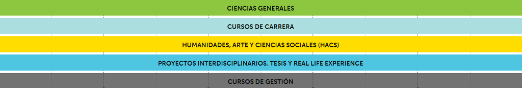

### 4.1.1 Ciencias Generales

En el grupo de **Ciencias Generales** tenemos 15 cursos (entre la malla 2018 y 2021). En la siguiente gráfica de barras, se pueden ver la cantidad de alumnos que han desaprobado los cursos de **Ciencias Generales**.

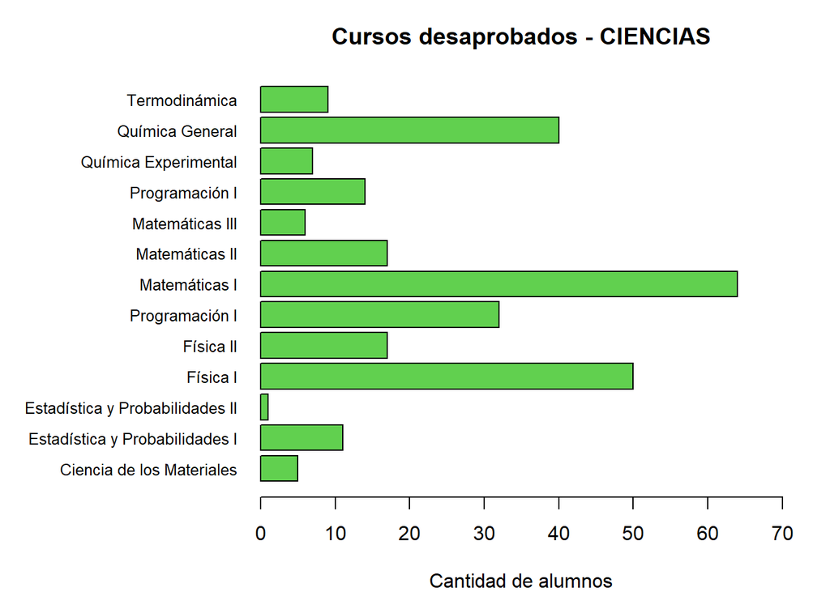

```r
par(mar = c(4, 11, 3, 2))
barplot(table(Cursos$`CIENCIAS GENERALES`),horiz=1,col= 3, las=1, cex.names = 0.8,xlim= c(0,70), main = "Cursos desaprobados - CIENCIAS", names.arg=c("Ciencia de los Materiales","Estadística y Probabilidades I","Estadística y Probabilidades II","Física I","Física II","Programación I","Matemáticas I", "Matemáticas II","Matemáticas III","Programación I","Química Experimental","Química General","Termodinámica"),xlab = "Cantidad de alumnos")
```

Como se puede apreciar, el curso con mayor cantidad de desaprobados es **Matemáticas I (malla 2018)**, también conocida como **Cálculo de una variable - vectorial** para la malla 2021. Además, el curso con menos desaprobados es **Estadística y Probabilidades** para la malla 2021 y **Ciencia de los Materiales** para la malla 2018. Finalmente, de los 15 cursos disponible en **Ciencias Generales**, solo se desaprobaron 13.

### 4.1.2 Cursos de Carrera

En el grupo de cursos de **Carrera**, al ser específicas para cada carrera, se decidió únicamente preguntar al encuestado si aprobó o no el curso.

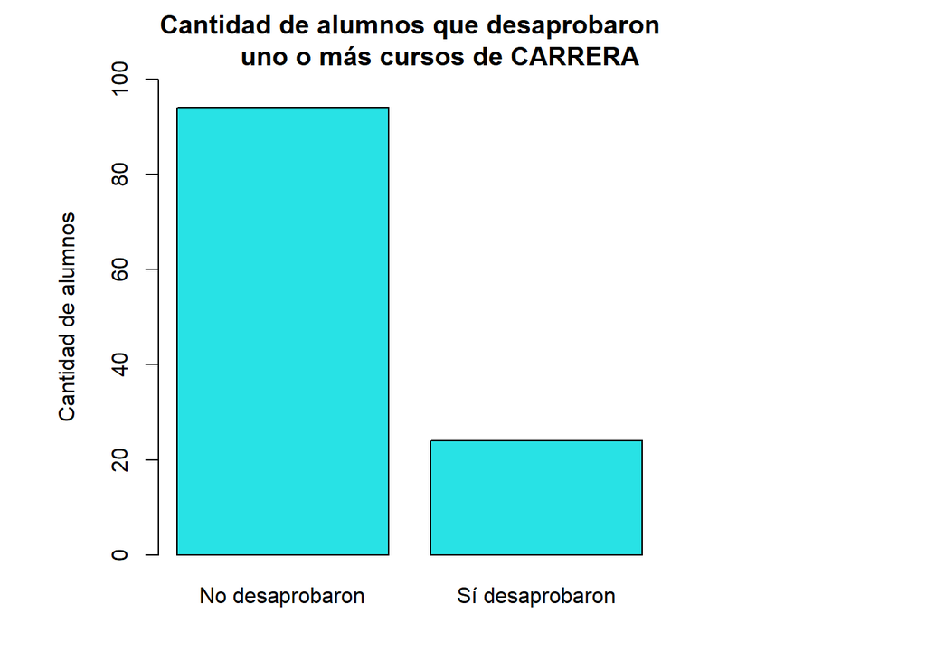

```r
par(mar = c(4, 6, 3, 10))
barplot(table(UTEC2$CARRERA_reprobado), ylim= c(0,100),names.arg=c("No desaprobaron","Sí desaprobaron"),col =5,ylab = "Cantidad de alumnos", main = "Cantidad de alumnos que desaprobaron
        uno o más cursos de CARRERA" )
```

Como se puede observar, una gran mayoría de estudiantes (94) no han desaprobado un curso de carrera, mientras que 24 de ellos sí han desaprobado.

### 4.1.3 Proyectos Interdisciplinarios, Tesis y Real Life Experience

En el grupo de **Proyectos Interdisciplinarios, Tesis y Real Life Experience** tenemos nueve cursos (entre la malla 2018 y 2021). En la siguiente gráfica de barras, se pueden ver la cantidad de alumnos que han desaprobado los cursos de **Proyectos Interdisciplinarios, Tesis y Real Life Experience**.

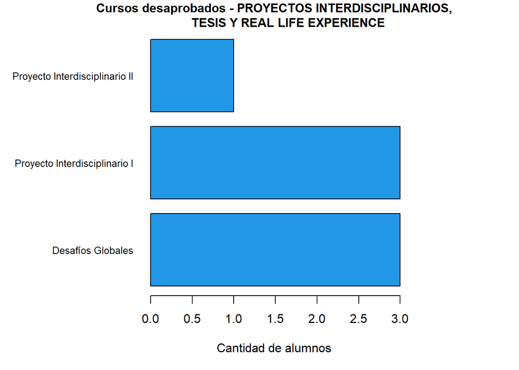

```r
par(mar = c(5, 10, 2, 8))
barplot(table(Cursos$`PROYECTOS INTERDISCIPLINARIOS, TESIS Y REAL LIFE EXPERIENCE`),col = 12,cex.names=0.8,las=1,horiz=1, xlab = "Cantidad de alumnos", main = "Cursos desaprobados - PROYECTOS INTERDISCIPLINARIOS,
        TESIS Y REAL LIFE EXPERIENCE", cex.main=1, names.arg=c( "Desafíos Globales", "Proyecto Interdisciplinario I","Proyecto Interdisciplinario II") )
```

Como se puede apreciar, los cursos con mayor cantidad de desaprobados es **Desafíos Globales (malla 2018)** y **Proyecto Interdisciplinario I (mallas 2018 y 2021)**. Además, el curso con menos desaprobados es **Proyecto Interdisciplinario II** para las mallas 2018 y 2021.

### 4.1.4 Humanidades, Artes y Ciencias Sociales (HACS)

En el grupo de **Humanidades, Artes y Ciencias Sociales (HACS)** tenemos 11 cursos (entre la malla 2018 y 2021). En la siguiente gráfica de barras, se pueden ver la cantidad de alumnos que han desaprobado los cursos de **Humanidades, Artes y Ciencias Sociales (HACS)**.

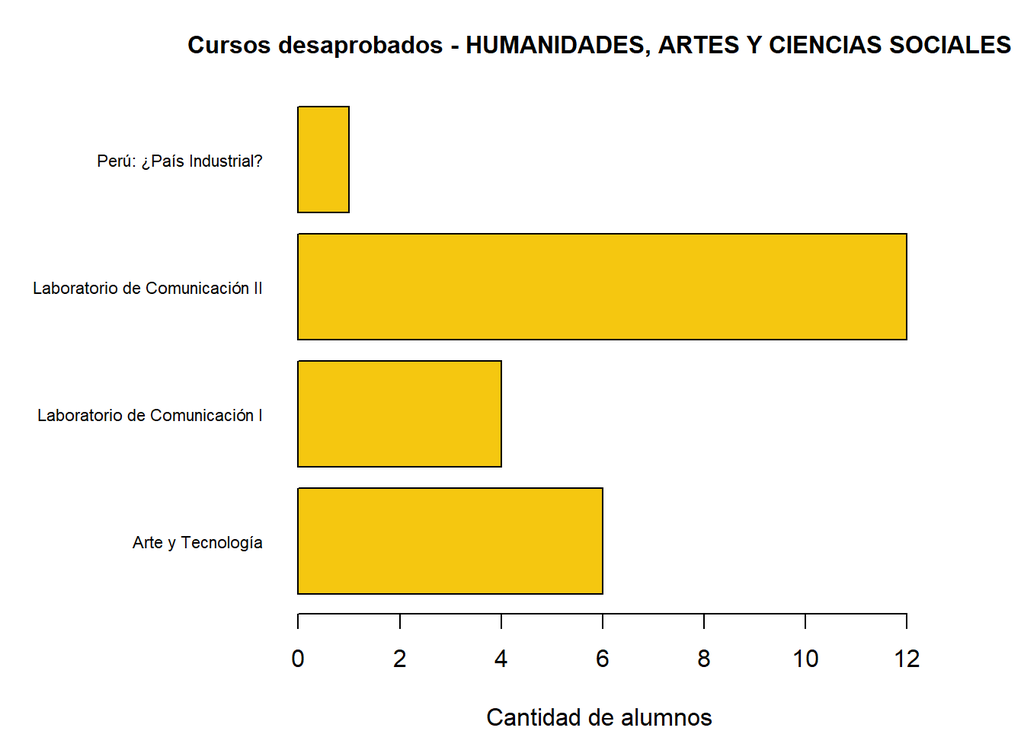

```r
par(mar = c(4, 10, 3, 4))
barplot(table(Cursos$`HUMANIDADES, ARTES Y CIENCIAS SOCIALES`),col = 7 ,horiz=1,cex.names=0.7,las=1, main = "Cursos desaprobados - HUMANIDADES, ARTES Y CIENCIAS SOCIALES", cex.main=1, xlab = "Cantidad de alumnos", names.arg=c("Arte y Tecnología","Laboratorio de Comunicación I","Laboratorio de Comunicación II", "Perú: ¿País Industrial?"))
```

Como se puede apreciar, el curso con mayor cantidad de desaprobados es **Laboratorio de Comunicación II (malla 2018 y 2021)**. Además, el curso con menos desaprobados es **Perú: ¿País Industrial?** para la malla 2018. Finalmente, de los 11 cursos disponible en **Humanidades, Artes y Ciencias Sociales (HACS)**, solo se desaprobaron 4.

### 4.1.5 Gestión

En el grupo de **Gestión** tenemos 10 cursos (entre la malla 2018 y 2021). En este caso, únicamente se obtuvo un desaprobado en el curso de **Finanzas Empresariales**, por lo que realizar un gráfico de barras no es necesario.

```r
table(Cursos$GESTIÓN)
```

```
##
## Finanzas Empresariales
##                      1
```

## 4.2 Edad

Empleando la función *summary* obtenemos los valores mínimos, máximos, la mediana, el promedio y el primer y tercer cuartil de la variable *Edad*. Esto nos brinda información relevante para conocer con mayor precisión las características del público al que dirigimos nuestro estudio, por lo tanto es considerado un descriptor descriptivo.

```r
summary(UTEC2$Edad)
```

```
##    Min. 1st Qu.  Median    Mean 3rd Qu.    Max.
##   16.00   18.00   19.00   19.01   20.00   31.00
```

Teniendo en cuenta a la muestra analizada, podemos observar que el rango de edades es pequeño y la mayoría de encuestados representan a una población joven teniendo como media la edad de 19.01. Sin embargo, no podemos ignorar los datos atípicos que abarcan hasta los 31 años y, aunque no representen a la población con esa edad por no ser una cantidad representativa, esto no influirá en los resultados y conclusiones de nuestro estudio de manera significativa.

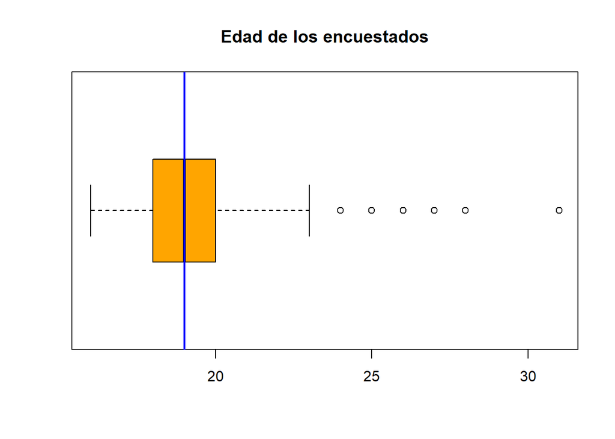

```r
boxplot(UTEC2$Edad,col= "orange", main = "Edad de los encuestados", horizontal = TRUE)
abline(v=mean(UTEC2$Edad),col="blue",lwd=2)
```

También se puede representar mediante un histograma:

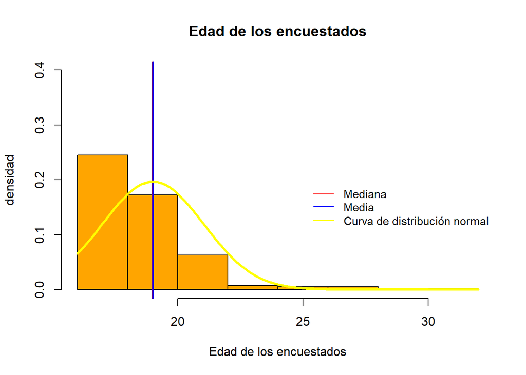

```r
hist(UTEC2$Edad,ylim = c(0,0.4), col= "orange",main="Edad de los encuestados",ylab="densidad",xlab="Edad de los encuestados",freq = FALSE)
abline(v=median(UTEC2$Edad),col="red",lwd=2)
abline(v=mean(UTEC2$Edad),col="blue",lwd=2)
legend(200,0.012,legend=c("Mediana","Media"),lwd=2,col=c("red","blue"))
legend(25,0.2,legend=c("Mediana","Media","Curva de distribución normal"),col=c("red","blue","yellow"),lty=1,bty="n",cex=0.9)
curve(dnorm(x, mean=mean(UTEC2$Edad), sd=sd(UTEC2$Edad)), add=TRUE, col="yellow", lwd=3)
```

El histograma cumple la función de dibujar la curva de distribución normal y describir gráficamente los valores de media y mediana esencialmente

Patrón: En el histograma podemos observar que la mediana y la media son ligeramente iguales, siendo la media igual a 19.01 y la mediana igual a 19. Aún así, la media es mayor a la mediana, lo que ocasiona que el histograma tenga un sesgo a la derecha.

El intervalo de confianza para la variable **Edad** con un nivel de confianza de **95%** y una significancia de **5%** es:

```r
nc = 0.95
alfa = 0.05
var = var(UTEC2$Edad)
n = nrow(UTEC2)
media = mean(UTEC2$Edad)
z = qnorm(1-alfa/2)

ICI <- media - z * sqrt(var/n)
ICS <- media + z * sqrt(var/n)
cat("(",round(ICI,2),";",round(ICS,2),")")
```

```
## ( 18.73 ; 19.29 )
```

## 4.3 Horas de sueño diaria

Para la representación de las horas de sueño diaria, utilizamos la función *summary* con la variable *Horas_sueño* para hallar la información más importante en relación a la cantidad de horas que duermen los encuestados. Nuevamente es una función que cumple para dar un análisis descriptivo de la variable.

```r
summary(UTEC2$Horas_sueño)
```

```
##    Min. 1st Qu.  Median    Mean 3rd Qu.    Max.    NA's
##   4.000   6.000   7.000   6.629   7.000  10.000       1
```

Al observar que el primer cuartil es 6 y el tercer cuartil 7, entendemos que los datos están muy concentrados entre esos dos valores. Esto nos permite apreciar que, probablemente existe algo que no le permita a la muestra escapar de ese rango, debido a que existen tan solo 3 valores atípicos. Con el fin de llegar a conclusiones más precisas, se requerirá un análisis más exhaustivo de los datos.

En la parte inferior se aprecia la gráfica de horas de sueño de nuestra población encuestada, a través, de la aplicación de la función boxplot, extrayendo los datos de la encuesta realizada.

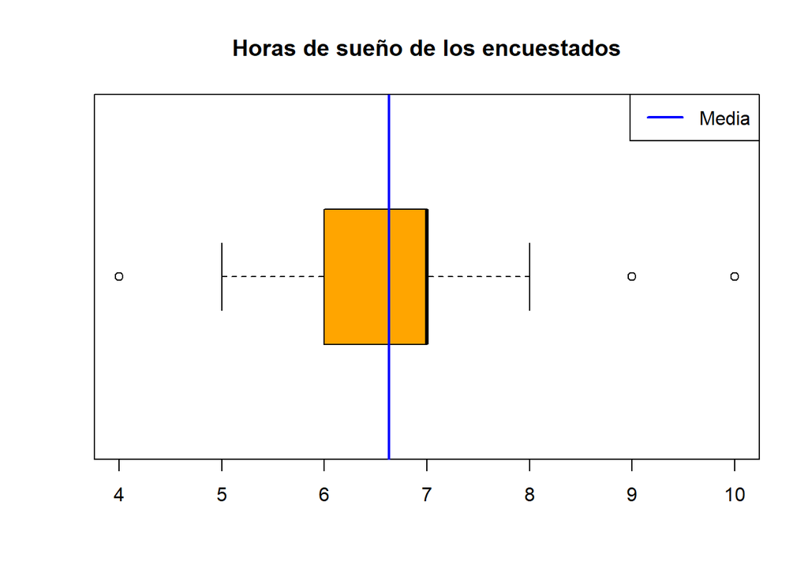

```r
boxplot(UTEC2$Horas_sueño,col= "orange", main = "Horas de sueño de los encuestados", horizontal = TRUE)
abline(v=mean(UTEC2$Horas_sueño, na.rm = 1),col="blue",lwd=2)
legend("topright",legend=c("Media"),lwd=2,col=c("blue"))
```

El gráfico de caja de bigote de la variable Horas de sueño cumple un papel netamente descriptivo. Este muestra gráficamente la concentración de datos y los datos atípicos mencionados anteriormente.

Patrón: Se puede observar que la mayoría de los alumnos cumple con dormir alrededor de 6 a 7 horas, es por ello, que de acuerdo al estudio realizado por la BBC, los alumnos no duermen dentro del rango recomendado para personas de su edad. En consecuencia, es posible que esta costumbre afecte su desarrollo y su desempeño académico.

El intervalo de confianza de la media para la variable **Horas_sueño** con un nivel de confianza de **95%** y una significancia de **5** es:

```r
nc = 0.95
alfa = 0.05
var2 = var(UTEC2$Horas_sueño, na.rm=1)
n2 = nrow(UTEC2)
media2 = mean(UTEC2$Horas_sueño,na.rm = 1)
z2 = qnorm(1-alfa/2)

ICI2 <- media2 - z2 * sqrt(var2/n2)
ICS2 <- media2 + z2 * sqrt(var2/n2)
cat("(",round(ICI2,2),";",round(ICS2,2),")")
```

```
## ( 6.48 ; 6.78 )
```

## 4.4 Alumnos encuestados por carrera

El siguiente gráfico descriptivo es un gráfico de barras, podemos apreciar la manera en que se distribuyen los encuestados en las distintas carreras de UTEC.

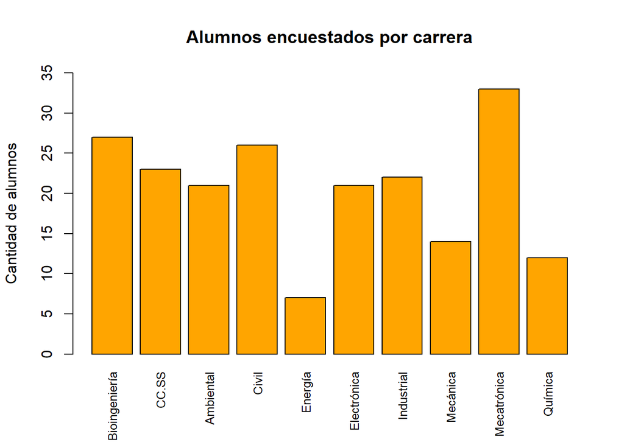

```r
barplot(table(UTEC2$Carrera),las=3, col= "orange", ylab = "Cantidad de alumnos", main="Alumnos encuestados por carrera",names.arg=c("Bioingeniería", "CC.SS", "Ambiental", "Civil","Energía","Electrónica","Industrial","Mecánica","Mecatrónica","Química"), cex.names=0.8, ylim= c(0,35)  )
```

Patrón: Podemos afirmar que de las 10 carreras incluidas en el estudio, 7 de ellas se encuentran con una cantidad similar de estudiantes, mientras que ingeniería de la energía, ingeniería mecánica e ingeniería química cuentan con una cantidad menor de representantes en relación al resto de carreras en el estudio. Por otro lado, tenemos que la moda se representa en la barra más alta, por lo que en este caso, la moda sería **Mecatrónica**.

## 4.5 Horas de deporte semanal

```r
summary(UTEC2$Horas_Deporte)
```

```
##    Min. 1st Qu.  Median    Mean 3rd Qu.    Max.
##    0.00    0.00    1.00    1.99    3.00   14.00
```

Observando el histograma y los descriptores numéricos de las horas de deporte realizadas en una semana, podemos apreciar que manejamos una variable unimodal sesgada hacia la derecha con una gran concentración de datos entre 0 y 2 horas. El hecho de que la media se encuentre en un valor tan cercano a 2, nos indica que la mayoría de casos de la muestra no realiza o realiza muy poco deporte; lo que nos servirá para ver cómo es que esta relación influye en su desarrollo académico (ya que el deporte es una gran forma de aliviar el estrés provocado por los estudios).

A través del uso de la función *hist* se ha obtenido el gráfico de las horas de deporte semanal que la población encuestada de estudiante de UTEC practica.

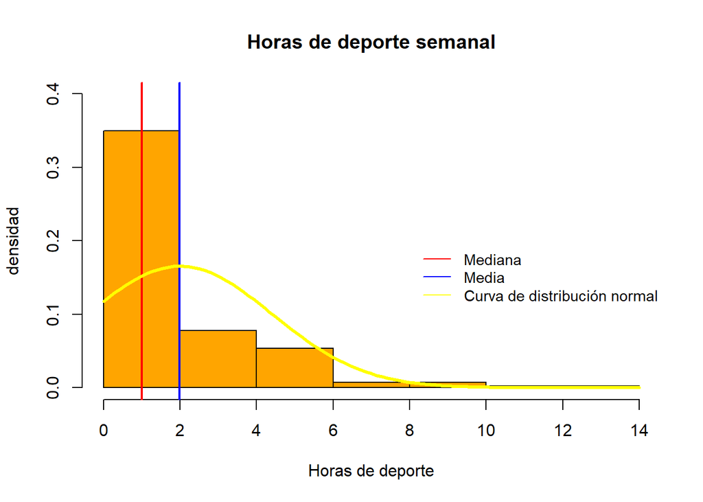

```r
hist(UTEC2$Horas_Deporte,ylim = c(0,0.4), col= "orange",main="Horas de deporte semanal",ylab="densidad",xlab="Horas de deporte",freq = FALSE)
abline(v=median(UTEC2$Horas_Deporte),col="red",lwd=2)
abline(v=mean(UTEC2$Horas_Deporte),col="blue",lwd=2)
legend(200,0.012,legend=c("Mediana","Media"),lwd=2,col=c("red","blue"))
legend(8,0.2,legend=c("Mediana","Media","Curva de distribución normal"),col=c("red","blue","yellow"),lty=1,bty="n",cex=0.9)
curve(dnorm(x, mean=mean(UTEC2$Horas_Deporte), sd=sd(UTEC2$Horas_Deporte)), add=TRUE, col="yellow", lwd=3)
```

Patrón : En promedio, los encuestados realizan 1.99 horas de ejercicio a la semana. En comparación a lo recomendado por la OMS, que son 150 minutos (2.5 horas) de actividad moderada diaria, no es una cantidad significativa para aliviar los niveles de estrés que los estudios provocan en los alumnos. En el histograma también se aprecia la curva de distribución sesgada a la derecha.

## 4.6 Escala económica

En el siguiente gráfico se logra observar la frecuencia relativa de las distintas escalas económicas de la muestra. Destaca la escala E con la mayor cantidad de alumnos.

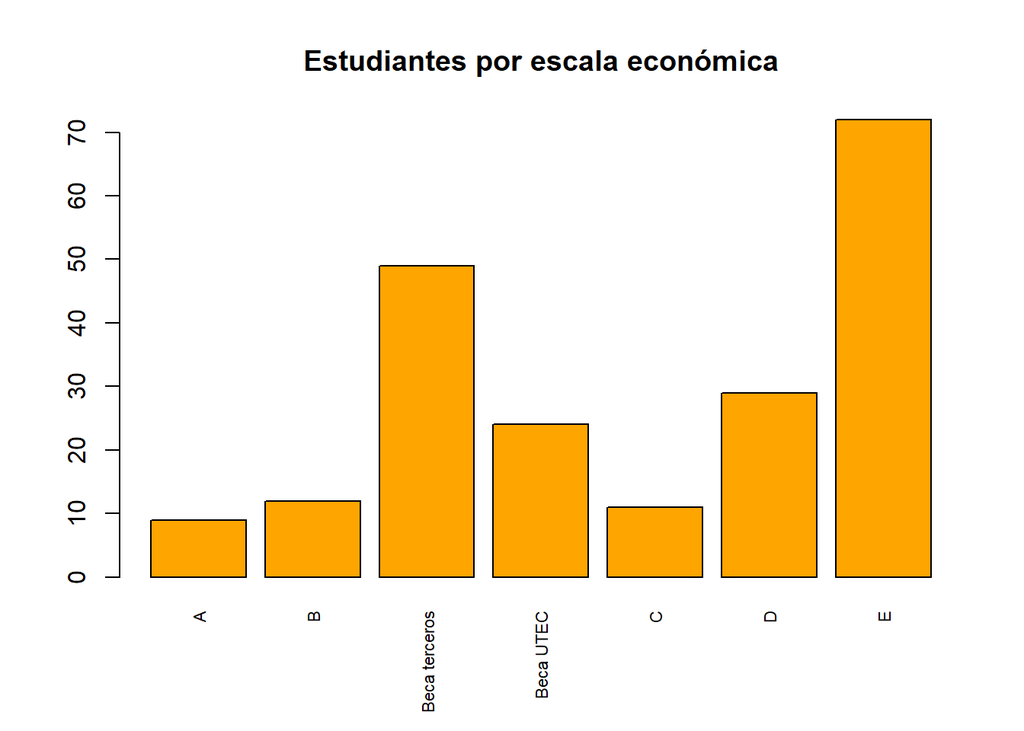

```r
barplot(table(UTEC2$Escala),las=3, col= "orange", main="Estudiantes por escala económica", names.arg =c("A","B","Beca terceros","Beca UTEC","C","D","E"),cex.names=0.7)
```

## 4.7 Frecuencia de alumnos en riesgo académico

El gráfico cumple con la finalidad de ser un descriptor gráfico con el cual concluimos que actualmente hay una cantidad menor de alumnos en riesgo académico que alumnos regulares en nuestra muestra de estudio; lo cual es lógico.

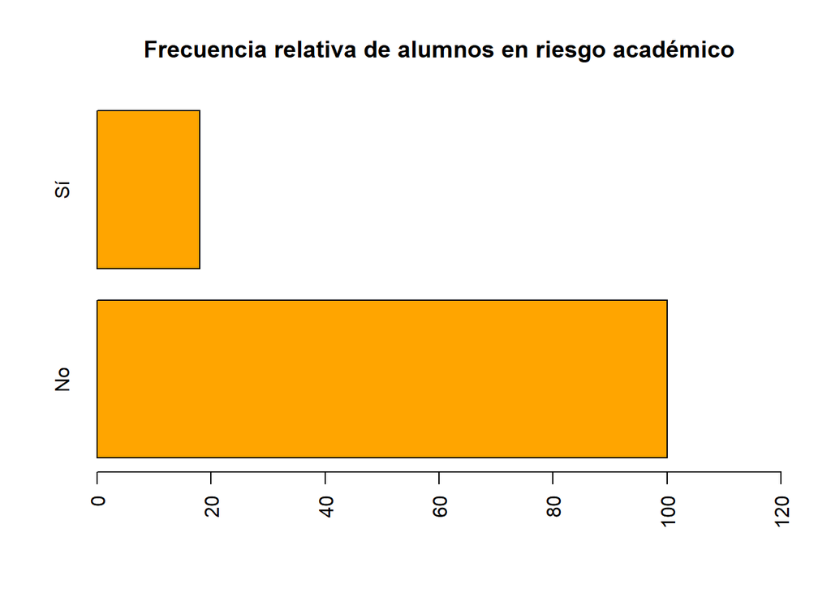

```r
barplot(table(UTEC2$Riesgo),las=3, col= "orange", main="Frecuencia relativa de alumnos en riesgo académico", horiz = TRUE , xlim = c(0,120) )
```

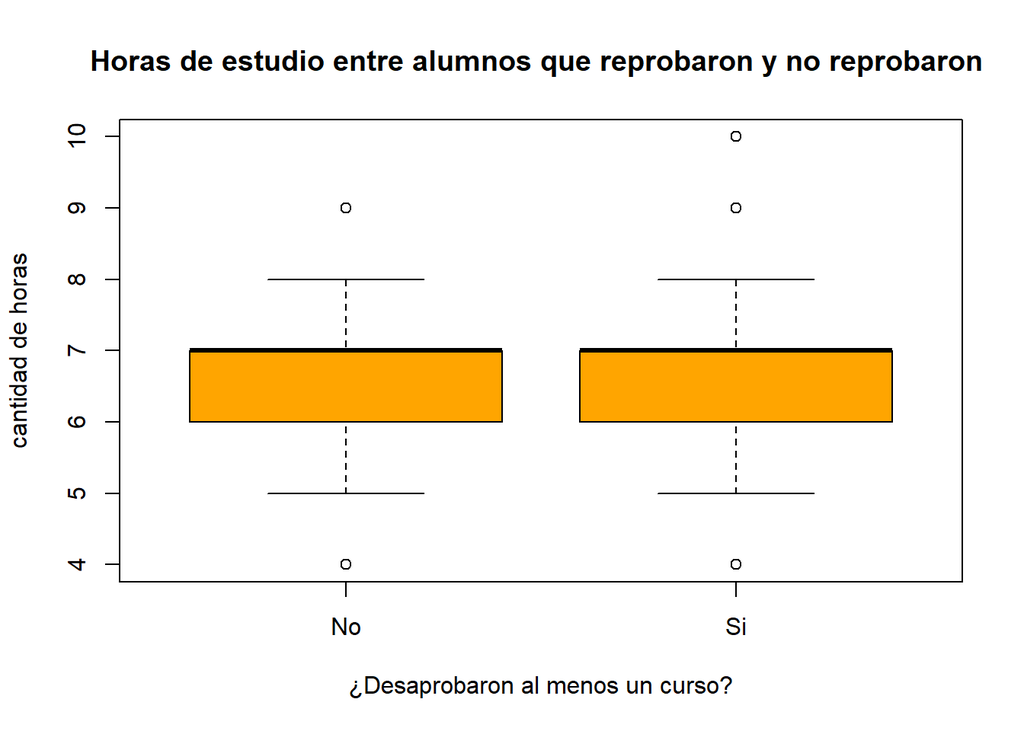

```r
boxplot(UTEC2$Horas_sueño ~ UTEC2$J_curso,main="Horas de estudio entre alumnos que reprobaron y no reprobaron ",ylab="cantidad de horas",xlab="¿Desaprobaron al menos un curso?", col="orange")
```

## 4.9 Horas de estudio semanales vs promedio primer ciclo

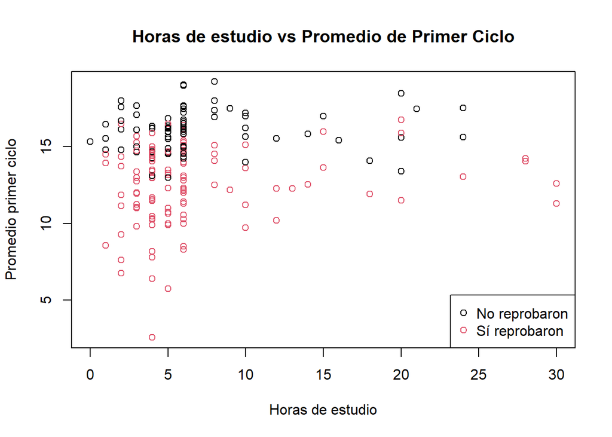

```r
plot(UTEC2$Prom_PrimerCiclo ~ UTEC2$Horas_estudio,xlab="Horas de estudio",ylab="Promedio primer ciclo",main="Horas de estudio vs Promedio de Primer Ciclo", col=as.factor(UTEC2$J_curso))
legend("bottomright", legend=c("No reprobaron","Sí reprobaron"),pch = 1, col=1:2, bty="y")
```

## 4.10 Horas de estudio vs promedio de último ciclo

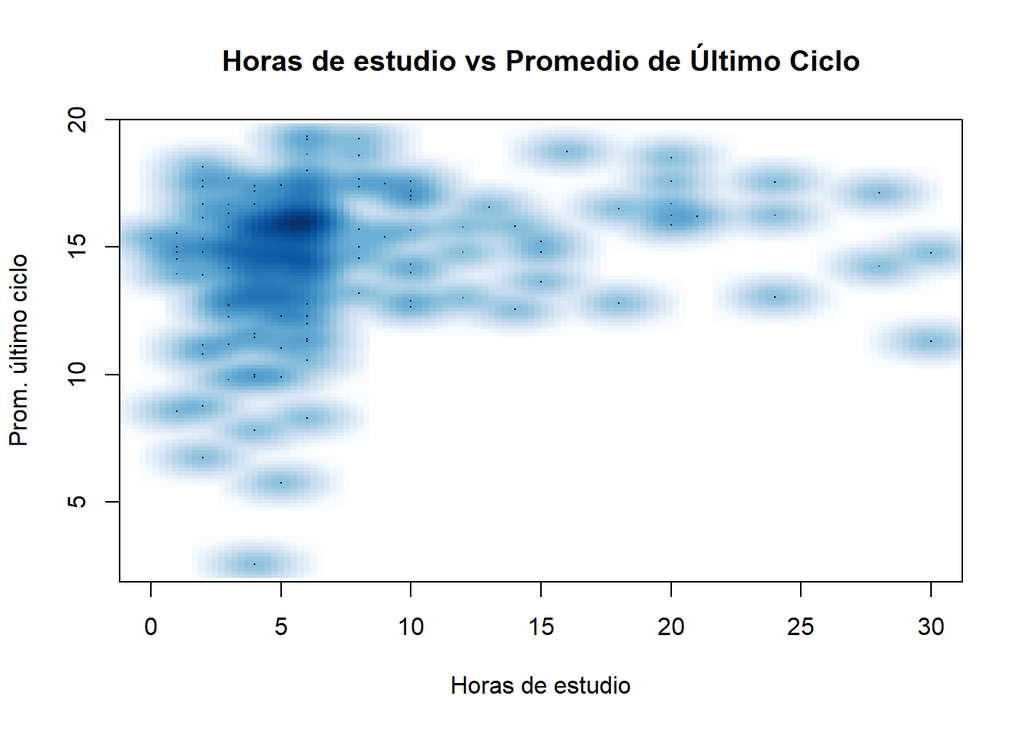

```r
smoothScatter(UTEC2$Prom_UltimoCiclo ~ UTEC2$Horas_estudio,xlab="Horas de estudio",ylab="Prom. último ciclo",main="Horas de estudio vs Promedio de Último Ciclo")
```

## 4.11 Proporción de desaprobados por carrera

A continuación se muestra la manera en que se distribuyen los desaprobados por las distintas carreras analizadas en el presente estudio; donde destacan las carreras de ingeniería industrial, ambiental y civil por tener la mayor proporción de desaprobados, más no necesariamente la mayor cantidad.

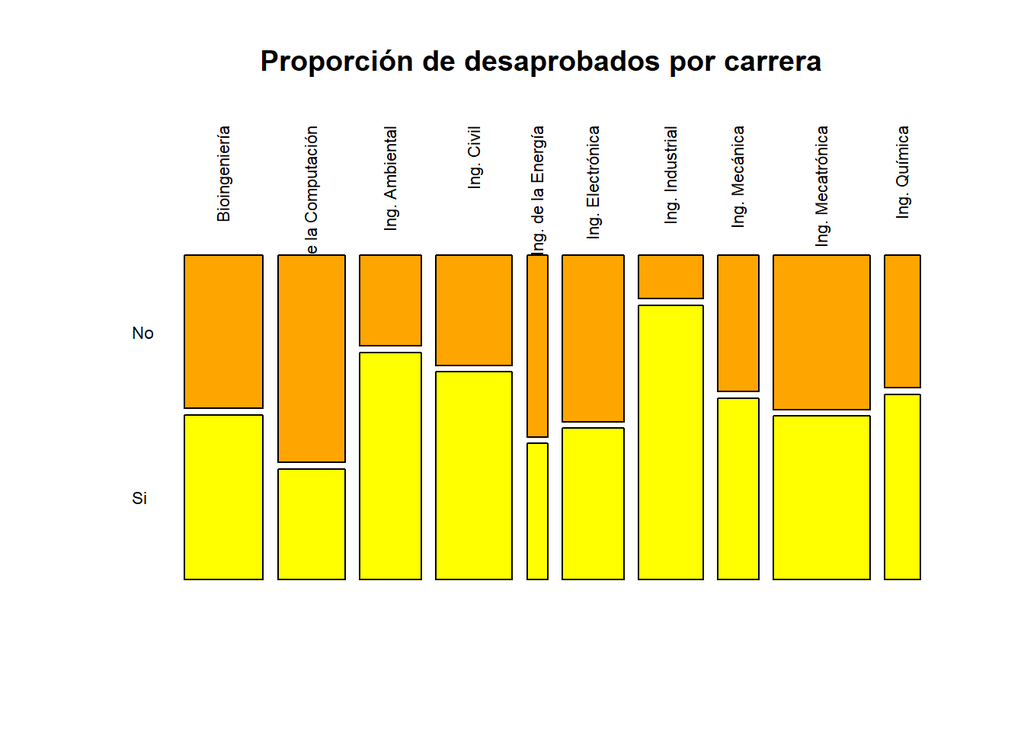

```r
mosaicplot(table(UTEC2$Carrera,UTEC2$J_curso),las=6,main="Proporción de desaprobados por carrera",col=c("orange","yellow"),cex.axis =0.7)
```

## 4.12 Proporción de desaprobados por escala de precios

Por medio de la siguiente representación, se expone la relación entre cada escala económica y si han reprobado algún curso o no. Del anterior gráfico se conocía que en la escala E había la mayor cantidad de alumnos y de este gráfico se conoce que también es la escala con mayor proporción de reprobados; por lo que podemos concluir que en esa escala es donde hay mayor cantidad de alumnos reprobados.

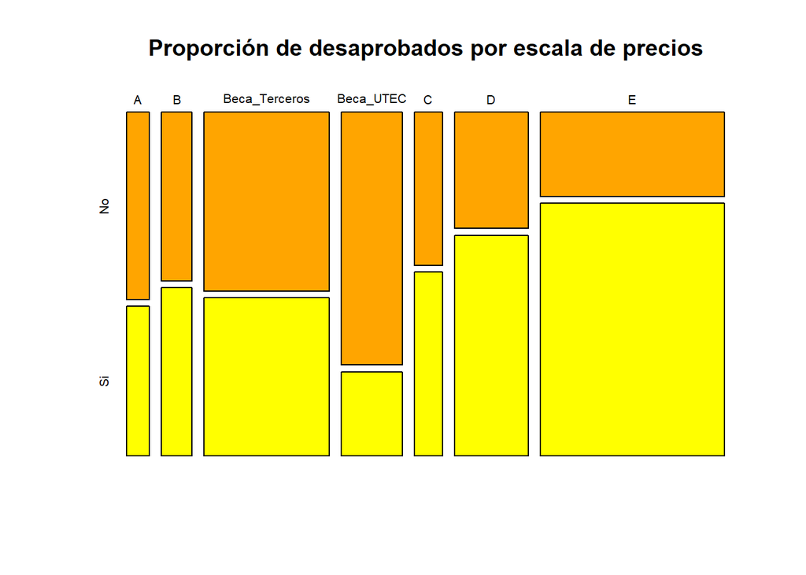

```r
mosaicplot(table(UTEC2$Escala,UTEC2$J_curso),main="Proporción de desaprobados por escala de precios",col=c("orange","yellow"))
```